# Fantastic Models and How to Find Them

Nate Selleck

10/5/2021

Example 1 - Annual Return of LOWA

$~$

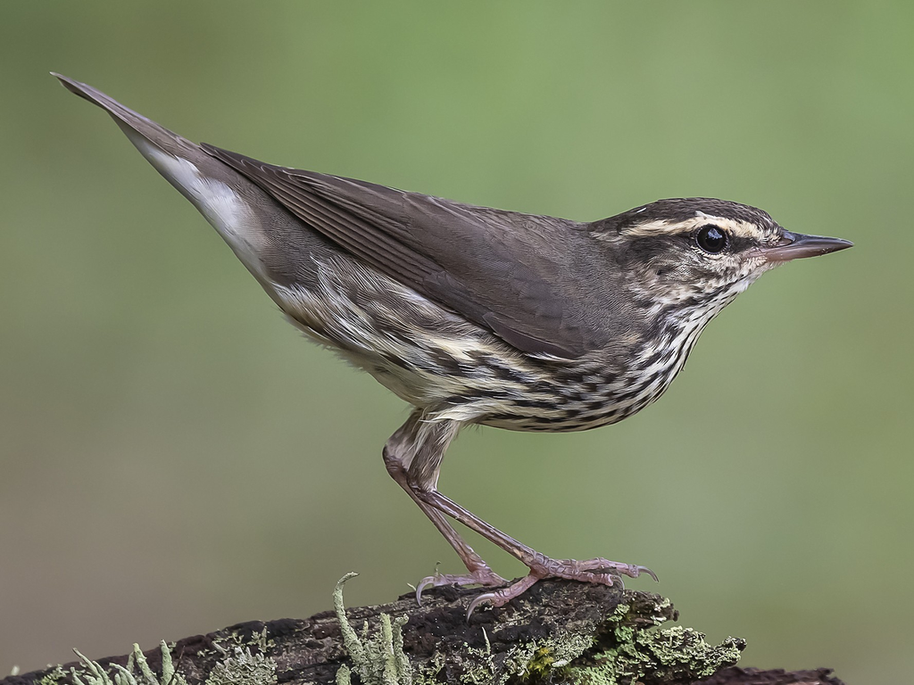

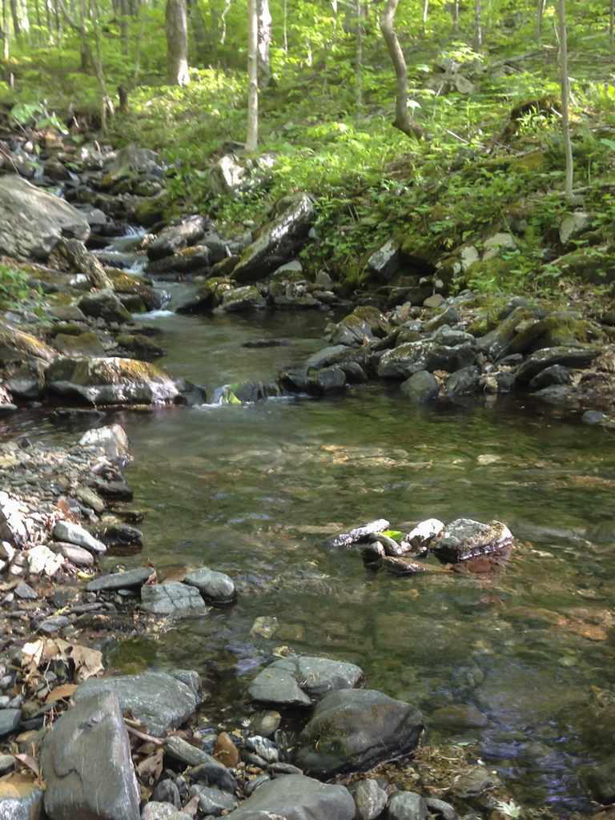

Image 2 - Typical Louisiana Waterthrush habitat.

$~$

First, I imported the data and cleaned it up. I then checked for correlation among the variables.

$~$

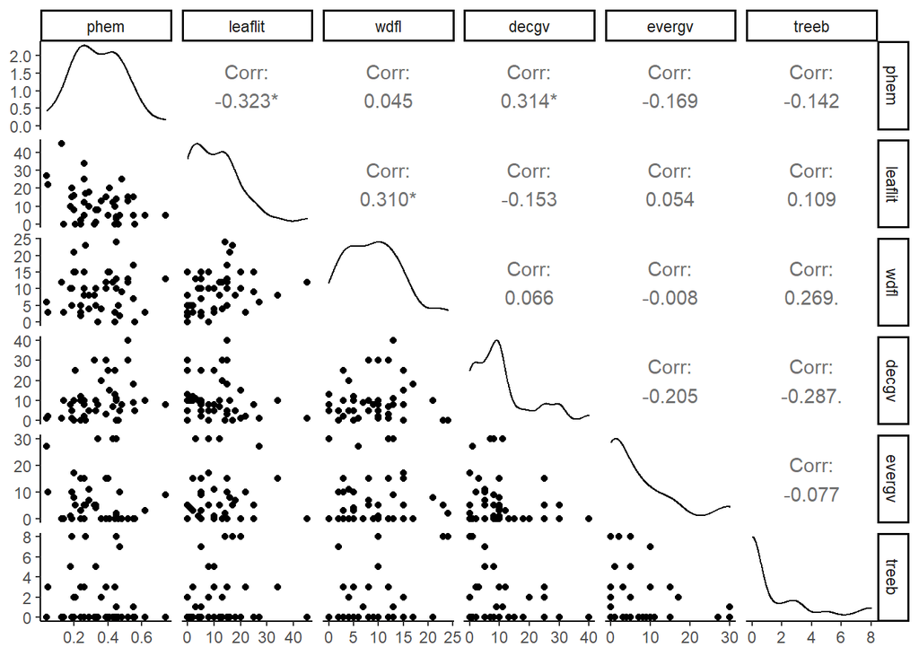

```r
lowa_return <- read.csv("data/lowa_return_data.csv")
lowa_return <- clean_names(lowa_return)
lowa_return <- na.omit(lowa_return)

Veg <- lowa_return[, c("phem", "leaflit", "wdfl", "decgv", "evergv", "treeb")]

ggpairs(Veg) + theme_classic()
```

It seems that the proportion of hemlock at the study site (phem) is correlated with leaf litter and deciduous ground vegetation (decgv). Based on this, I modeled the data and checked for collinearity.

$~$

```r
model_lowa1 <- lm(i_return ~ phem + leaflit + wdfl + decgv + evergv + treeb, data=lowa_return)
anova (model_lowa1)
```

|  | Df | Sum Sq | Mean Sq | F value | Pr(>F) |
| --- | --- | --- | --- | --- | --- |
| phem | 1 | 7.260091e-03 | 7.260091e-03 | 0.0332186305 | 0.85634770 |
| leaflit | 1 | 5.174424e-01 | 5.174424e-01 | 2.3675637311 | 0.13216664 |
| wdfl | 1 | 8.493454e-02 | 8.493454e-02 | 0.3886189517 | 0.53675032 |
| decgv | 1 | 6.718074e-01 | 6.718074e-01 | 3.0738623351 | 0.08762467 |
| evergv | 1 | 2.679446e-05 | 2.679446e-05 | 0.0001225983 | 0.99122360 |
| treeb | 1 | 1.213446e+00 | 1.213446e+00 | 5.5521382036 | 0.02371709 |
| Residuals | 38 | 8.305082e+00 | 2.185548e-01 | NA | NA |

```r
performance::check_collinearity(model_lowa1)
```

|  | Term | VIF | SE_factor |
| --- | --- | --- | --- |
| 1 | phem | 1.263812 | 1.124194 |
| 2 | leaflit | 1.278761 | 1.130823 |
| 3 | wdfl | 1.264440 | 1.124473 |
| 4 | decgv | 1.274675 | 1.129015 |
| 5 | evergv | 1.086931 | 1.042560 |
| 6 | treeb | 1.241366 | 1.114166 |

$~$ Thankfully, all of the variables seem to have low correlation.

```r
options(na.action = "na.fail") # otherwise blows up with NA values
dredge_lowa<-dredge(model_lowa1)
```

```
## Fixed term is "(Intercept)"
```

```r
dredge_lowa
```

|  | (Intercept) | decgv | evergv | leaflit | phem | treeb | wdfl | df | logLik | AICc | delta | weight |
| --- | --- | --- | --- | --- | --- | --- | --- | --- | --- | --- | --- | --- |
| 18 | 0.3068924 | 0.01856432 | NA | NA | NA | 0.06975951 | NA | 4 | -27.38846 | 63.77692 | 0.0000000 | 0.1550835939 |
| 22 | 0.4315204 | 0.01717791 | NA | -0.010211238 | NA | 0.07272545 | NA | 5 | -26.26117 | 64.06080 | 0.2838799 | 0.1345619024 |
| 50 | 0.3753214 | 0.01951060 | NA | NA | NA | 0.07731052 | -0.0098218594 | 5 | -27.04352 | 65.62551 | 1.8485838 | 0.0615390790 |
| 30 | 0.5630037 | 0.01871177 | NA | -0.011809986 | -0.37178755 | 0.07187675 | NA | 6 | -25.95105 | 66.11262 | 2.3356924 | 0.0482366004 |
| 20 | 0.2747229 | 0.01930179 | 3.265079e-03 | NA | NA | 0.07150487 | NA | 5 | -27.30280 | 66.14406 | 2.3671395 | 0.0474840813 |
| 26 | 0.3491741 | 0.01922550 | NA | NA | -0.14039224 | 0.06926367 | NA | 5 | -27.34280 | 66.22406 | 2.4471382 | 0.0456222346 |
| 24 | 0.3966893 | 0.01799222 | 3.671377e-03 | -0.010321156 | NA | 0.07471993 | NA | 6 | -26.14736 | 66.50525 | 2.7283292 | 0.0396384536 |
| 54 | 0.4535050 | 0.01774580 | NA | -0.009344828 | NA | 0.07606663 | -0.0046733273 | 6 | -26.18790 | 66.58632 | 2.8093948 | 0.0380639209 |
| 2 | 0.4588280 | 0.01351647 | NA | NA | NA | NA | NA | 3 | -30.13747 | 66.86031 | 3.0833831 | 0.0331908005 |
| 21 | 0.6604179 | NA | NA | -0.012265411 | NA | 0.05410879 | NA | 4 | -28.97242 | 66.94483 | 3.1679086 | 0.0318172946 |

[output cut: 54 more lines]

$~$ Because of the large(ish) amount of models, I decided to subset all models with a delta AIC less than 5. When that still returned a fair amount, I subsetted all of those with a delta AIC less than 2.

$~$

```r
subset(dredge_lowa, delta <5)
```

|  | (Intercept) | decgv | evergv | leaflit | phem | treeb | wdfl | df | logLik | AICc | delta | weight |
| --- | --- | --- | --- | --- | --- | --- | --- | --- | --- | --- | --- | --- |
| 18 | 0.3068924 | 0.01856432 | NA | NA | NA | 0.06975951 | NA | 4 | -27.38846 | 63.77692 | 0.0000000 | 0.20146311 |
| 22 | 0.4315204 | 0.01717791 | NA | -0.010211238 | NA | 0.07272545 | NA | 5 | -26.26117 | 64.06080 | 0.2838799 | 0.17480417 |
| 50 | 0.3753214 | 0.01951060 | NA | NA | NA | 0.07731052 | -0.009821859 | 5 | -27.04352 | 65.62551 | 1.8485838 | 0.07994304 |
| 30 | 0.5630037 | 0.01871177 | NA | -0.011809986 | -0.3717876 | 0.07187675 | NA | 6 | -25.95105 | 66.11262 | 2.3356924 | 0.06266230 |
| 20 | 0.2747229 | 0.01930179 | 0.003265079 | NA | NA | 0.07150487 | NA | 5 | -27.30280 | 66.14406 | 2.3671395 | 0.06168474 |
| 26 | 0.3491741 | 0.01922550 | NA | NA | -0.1403922 | 0.06926367 | NA | 5 | -27.34280 | 66.22406 | 2.4471382 | 0.05926608 |
| 24 | 0.3966893 | 0.01799222 | 0.003671377 | -0.010321156 | NA | 0.07471993 | NA | 6 | -26.14736 | 66.50525 | 2.7283292 | 0.05149278 |
| 54 | 0.4535050 | 0.01774580 | NA | -0.009344828 | NA | 0.07606663 | -0.004673327 | 6 | -26.18790 | 66.58632 | 2.8093948 | 0.04944737 |
| 2 | 0.4588280 | 0.01351647 | NA | NA | NA | NA | NA | 3 | -30.13747 | 66.86031 | 3.0833831 | 0.04311689 |
| 21 | 0.6604179 | NA | NA | -0.012265411 | NA | 0.05410879 | NA | 4 | -28.97242 | 66.94483 | 3.1679086 | 0.04133262 |

[output cut: 7 more lines]

```r
subset(dredge_lowa, delta<2)
```

|  | (Intercept) | decgv | evergv | leaflit | phem | treeb | wdfl | df | logLik | AICc | delta | weight |
| --- | --- | --- | --- | --- | --- | --- | --- | --- | --- | --- | --- | --- |
| 18 | 0.3068924 | 0.01856432 | NA | NA | NA | 0.06975951 | NA | 4 | -27.38846 | 63.77692 | 0.0000000 | 0.4416014 |
| 22 | 0.4315204 | 0.01717791 | NA | -0.01021124 | NA | 0.07272545 | NA | 5 | -26.26117 | 64.06080 | 0.2838799 | 0.3831658 |
| 50 | 0.3753214 | 0.01951060 | NA | NA | NA | 0.07731052 | -0.009821859 | 5 | -27.04352 | 65.62551 | 1.8485838 | 0.1752329 |

```r
importance(dredge_lowa)
```

```
##                      decgv treeb leaflit wdfl phem evergv
## Sum of weights:      0.78  0.78  0.46    0.24 0.24 0.23
## N containing models:   32    32    32      32   32   32
```

$~$ Only three models had a delta AIC less than 2. The two most important variables were the percentage of deciduous ground vegetation and the percentage of live tree boles. Both appeared in 32 of the 64 models.

```r
model.avg(dredge_lowa, revised.var = TRUE)
```

```
##
## Call:
## model.avg(object = dredge_lowa, revised.var = TRUE)
##
## Component models:
## '15'     '135'    '156'    '1345'   '125'    '145'    '1235'   '1356'
## '1'      '35'     '5'      '13'     '(Null)' '3'      '1256'   '1456'
## '1245'   '12345'  '13456'  '14'     '12356'  '16'     '12'     '345'
## '356'    '235'    '134'    '45'     '56'     '25'     '2'      '4'
## '36'     '6'      '136'    '34'     '123'    '23'     '12456'  '146'
## '124'    '123456' '126'    '1346'   '456'    '3456'   '2345'   '2356'
## '256'    '245'    '1234'   '24'     '26'     '346'    '46'     '236'
## '234'    '1236'   '1246'   '2456'   '12346'  '246'    '23456'  '2346'
##
## Coefficients:
##        (Intercept)      decgv      treeb     leaflit        wdfl       phem
## full      0.456607 0.01389891 0.05450763 -0.00494223 -0.00118506 -0.0467789
## subset    0.456607 0.01772469 0.06955344 -0.01074540 -0.00487408 -0.1969235
##              evergv
## full   0.0004390817
## subset 0.0019496450
```

```r
summary(model.avg(dredge_lowa, subset = delta <2 ))
```

```
##
## Call:
## model.avg(object = dredge_lowa, subset = delta < 2)
##
## Component model call:
## lm(formula = i_return ~ <3 unique rhs>, data = lowa_return)
##
## Component models:
##     df logLik  AICc delta weight
## 13   4 -27.39 63.78  0.00   0.44
## 123  5 -26.26 64.06  0.28   0.38
## 134  5 -27.04 65.63  1.85   0.18
##
## Term codes:
##   decgv leaflit   treeb    wdfl
##       1       2       3       4
##
## Model-averaged coefficients:
## (full average)
##              Estimate Std. Error Adjusted SE z value Pr(>|z|)
## (Intercept)  0.366637   0.147720    0.151527   2.420   0.0155 *
## decgv        0.018199   0.007592    0.007817   2.328   0.0199 *
## treeb        0.072219   0.030148    0.031047   2.326   0.0200 *
## leaflit     -0.003913   0.006604    0.006692   0.585   0.5588
## wdfl        -0.001721   0.006374    0.006502   0.265   0.7912
##
## (conditional average)
##              Estimate Std. Error Adjusted SE z value Pr(>|z|)
## (Intercept)  0.366637   0.147720    0.151527   2.420   0.0155 *
## decgv        0.018199   0.007592    0.007817   2.328   0.0199 *
## treeb        0.072219   0.030148    0.031047   2.326   0.0200 *
## leaflit     -0.010211   0.007036    0.007249   1.409   0.1590
## wdfl        -0.009822   0.012341    0.012716   0.772   0.4399
## ---
## Signif. codes:  0 '***' 0.001 '**' 0.01 '*' 0.05 '.' 0.1 ' ' 1
```

$~$ The summary just further reinforces that deciduous ground vegetation and live tree boles are the two most important variables, with both having significant effects on whether birds return to the previous season’s nesting site.

$~$

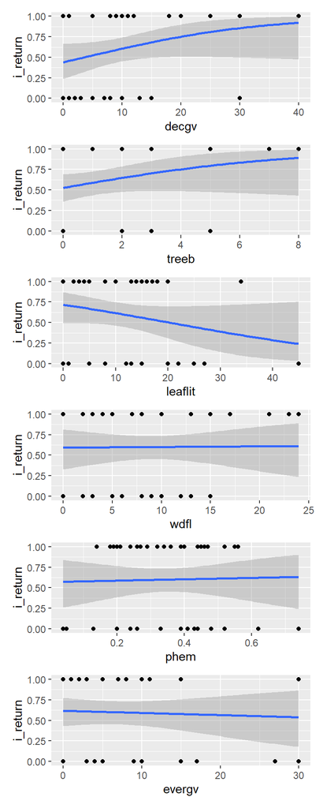

```r
l1 <- ggplot(lowa_return, aes(decgv, i_return)) +
  geom_point() +
  geom_smooth(method="glm", method.args=list(family="binomial"(link="logit")))

l2 <- ggplot(lowa_return, aes(treeb, i_return)) +
  geom_point() +
  geom_smooth(method="glm", method.args=list(family="binomial"(link="logit")))

l3 <- ggplot(lowa_return, aes(leaflit, i_return)) +
  geom_point() +
  geom_smooth(method="glm", method.args=list(family="binomial"(link="logit")))

l4 <- ggplot(lowa_return, aes(wdfl, i_return)) +
  geom_point() +
  geom_smooth(method="glm", method.args=list(family="binomial"(link="logit")))

l5 <- ggplot(lowa_return, aes(phem, i_return)) +
  geom_point() +
  geom_smooth(method="glm", method.args=list(family="binomial"(link="logit")))

l6 <- ggplot(lowa_return, aes(evergv, i_return)) +
  geom_point() +
  geom_smooth(method="glm", method.args=list(family="binomial"(link="logit")))

l1 / l2 / l3 / l4 / l5 / l6
```

Example 2 - Nest Survival $~$

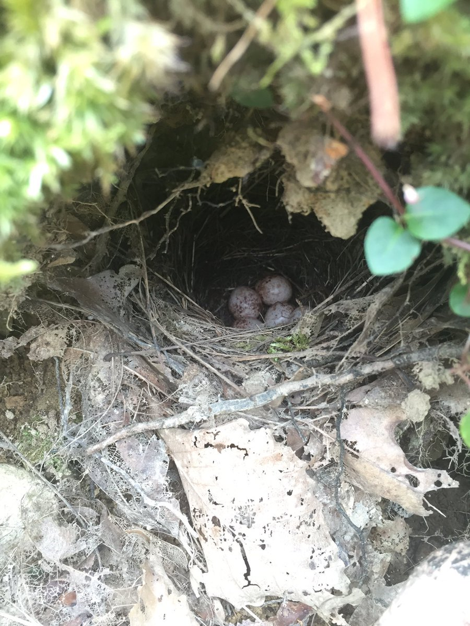

Image 3 - A Louisiana Waterthrush nest

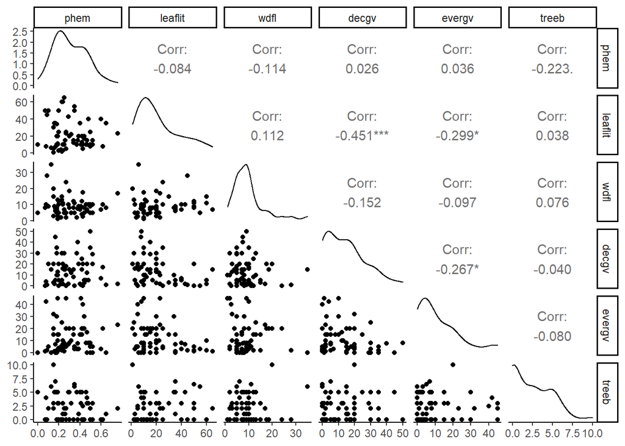

```r
lowa_survival <- read.csv("data/lowa_nest_survival.csv")
lowa_survival <- clean_names(lowa_survival)
lowa_survival <- na.omit(lowa_survival)

surv <- lowa_survival[, c("phem", "leaflit", "wdfl", "decgv", "evergv", "treeb")]

ggpairs(surv) + theme_classic()
```

```r
model_lowa2 <- lm(f ~ phem + leaflit + wdfl + decgv + evergv + treeb, data=lowa_survival)
anova (model_lowa2)
```

|  | Df | Sum Sq | Mean Sq | F value | Pr(>F) |
| --- | --- | --- | --- | --- | --- |
| phem | 1 | 0.148168672 | 0.148168672 | 0.57555342 | 0.45113256 |
| leaflit | 1 | 0.878241112 | 0.878241112 | 3.41148144 | 0.06984735 |
| wdfl | 1 | 0.044390435 | 0.044390435 | 0.17243231 | 0.67949130 |
| decgv | 1 | 0.195489848 | 0.195489848 | 0.75937004 | 0.38711861 |
| evergv | 1 | 0.005971865 | 0.005971865 | 0.02319740 | 0.87947347 |
| treeb | 1 | 0.011784068 | 0.011784068 | 0.04577459 | 0.83133643 |
| Residuals | 58 | 14.931338615 | 0.257436873 | NA | NA |

```r
performance::check_collinearity(model_lowa2)
```

|  | Term | VIF | SE_factor |
| --- | --- | --- | --- |
| 1 | phem | 1.069493 | 1.034163 |
| 2 | leaflit | 1.657606 | 1.287480 |
| 3 | wdfl | 1.059736 | 1.029435 |
| 4 | decgv | 1.667650 | 1.291375 |
| 5 | evergv | 1.451361 | 1.204725 |
| 6 | treeb | 1.064703 | 1.031844 |

```r
options(na.action = "na.fail") # otherwise blows up with NA values
dredge_lowa2 <- dredge(model_lowa2)
```

```
## Fixed term is "(Intercept)"
```

```r
dredge_lowa2
```

|  | (Intercept) | decgv | evergv | leaflit | phem | treeb | wdfl | df | logLik | AICc | delta | weight |
| --- | --- | --- | --- | --- | --- | --- | --- | --- | --- | --- | --- | --- |
| 5 | 0.6346222 | NA | NA | -0.007277559 | NA | NA | NA | 3 | -45.18052 | 96.75448 | 0.0000000 | 0.1126198359 |
| 2 | 0.3550612 | 0.008549401 | NA | NA | NA | NA | NA | 3 | -45.64154 | 97.67652 | 0.9220463 | 0.0710223572 |
| 6 | 0.5225782 | 0.005203838 | NA | -0.005529954 | NA | NA | NA | 4 | -44.72850 | 98.12366 | 1.3691798 | 0.0567938453 |
| 1 | 0.4769231 | NA | NA | NA | NA | NA | NA | 2 | -47.10713 | 98.40782 | 1.6533381 | 0.0492716468 |
| 13 | 0.5543066 | NA | NA | -0.007084436 | 0.2441292 | NA | NA | 4 | -44.98194 | 98.63054 | 1.8760652 | 0.0440790796 |
| 37 | 0.6769842 | NA | NA | -0.007071849 | NA | NA | -0.005042706 | 4 | -45.05597 | 98.77861 | 2.0241290 | 0.0409336872 |
| 21 | 0.6577412 | NA | NA | -0.007219848 | NA | -0.010490203 | NA | 4 | -45.09541 | 98.85749 | 2.1030114 | 0.0393506379 |
| 7 | 0.6576515 | NA | -0.0013595139 | -0.007580212 | NA | NA | NA | 4 | -45.14544 | 98.95754 | 2.2030623 | 0.0374305303 |
| 4 | 0.2871533 | 0.009689253 | 0.0042640561 | NA | NA | NA | NA | 4 | -45.29297 | 99.25261 | 2.4981362 | 0.0322962066 |
| 10 | 0.2660135 | 0.008455337 | NA | NA | 0.2898498 | NA | NA | 4 | -45.36345 | 99.39357 | 2.6390952 | 0.0300983467 |

[output cut: 54 more lines]

```r
subset(dredge_lowa2, delta<2)
```

|  | (Intercept) | decgv | evergv | leaflit | phem | treeb | wdfl | df | logLik | AICc | delta | weight |
| --- | --- | --- | --- | --- | --- | --- | --- | --- | --- | --- | --- | --- |
| 5 | 0.6346222 | NA | NA | -0.007277559 | NA | NA | NA | 3 | -45.18052 | 96.75448 | 0.0000000 | 0.3374005 |
| 2 | 0.3550612 | 0.008549401 | NA | NA | NA | NA | NA | 3 | -45.64154 | 97.67652 | 0.9220463 | 0.2127776 |
| 6 | 0.5225782 | 0.005203838 | NA | -0.005529954 | NA | NA | NA | 4 | -44.72850 | 98.12366 | 1.3691798 | 0.1701501 |
| 1 | 0.4769231 | NA | NA | NA | NA | NA | NA | 2 | -47.10713 | 98.40782 | 1.6533381 | 0.1476141 |
| 13 | 0.5543066 | NA | NA | -0.007084436 | 0.2441292 | NA | NA | 4 | -44.98194 | 98.63054 | 1.8760652 | 0.1320576 |

```r
importance(dredge_lowa2)
```

```
##                      leaflit decgv phem wdfl evergv treeb
## Sum of weights:      0.56    0.44  0.28 0.26 0.26   0.25
## N containing models:   32      32    32   32   32     32
```

```r
model.avg(dredge_lowa2, revised.var = TRUE)
```

```
##
## Call:
## model.avg(object = dredge_lowa2, revised.var = TRUE)
##
## Component models:
## '3'      '1'      '13'     '(Null)' '34'     '36'     '35'     '23'
## '12'     '14'     '16'     '15'     '4'      '134'    '6'      '136'
## '135'    '5'      '123'    '2'      '346'    '345'    '234'    '356'
## '236'    '124'    '235'    '126'    '125'    '146'    '145'    '46'
## '156'    '45'     '24'     '56'     '26'     '1346'   '1345'   '1234'
## '25'     '1356'   '1235'   '1236'   '2346'   '3456'   '2345'   '2356'
## '1246'   '1245'   '1256'   '1456'   '456'    '246'    '245'    '256'
## '13456'  '12346'  '12345'  '12356'  '23456'  '12456'  '2456'   '123456'
##
## Coefficients:
##        (Intercept)      leaflit       decgv       phem         wdfl
## full     0.5018164 -0.003686937 0.003234430 0.07201885 -0.001265213
## subset   0.5018164 -0.006630070 0.007341124 0.25798577 -0.004877314
##               treeb       evergv
## full   -0.002379054 0.0003063556
## subset -0.009506670 0.0011834256
```

```r
summary(model.avg(dredge_lowa2, subset = delta <2 ))
```

```
##
## Call:
## model.avg(object = dredge_lowa2, subset = delta < 2)
##
## Component model call:
## lm(formula = f ~ <5 unique rhs>, data = lowa_survival)
##
## Component models:
##        df logLik  AICc delta weight
## 2       3 -45.18 96.75  0.00   0.34
## 1       3 -45.64 97.68  0.92   0.21
## 12      4 -44.73 98.12  1.37   0.17
## (Null)  2 -47.11 98.41  1.65   0.15
## 23      4 -44.98 98.63  1.88   0.13
##
## Term codes:
##   decgv leaflit    phem
##       1       2       3
##
## Model-averaged coefficients:
## (full average)
##              Estimate Std. Error Adjusted SE z value Pr(>|z|)
## (Intercept)  0.522189   0.156061    0.157803   3.309 0.000936 ***
## leaflit     -0.004332   0.004514    0.004555   0.951 0.341618
## decgv        0.002705   0.004848    0.004892   0.553 0.580339
## phem         0.032239   0.165963    0.168453   0.191 0.848225
##
## (conditional average)
##              Estimate Std. Error Adjusted SE z value Pr(>|z|)
## (Intercept)  0.522189   0.156061    0.157803   3.309 0.000936 ***
## leaflit     -0.006773   0.003914    0.003989   1.698 0.089521 .
## decgv        0.007063   0.005531    0.005631   1.254 0.209728
## phem         0.244129   0.396036    0.403918   0.604 0.545576
## ---
## Signif. codes:  0 '***' 0.001 '**' 0.01 '*' 0.05 '.' 0.1 ' ' 1
```

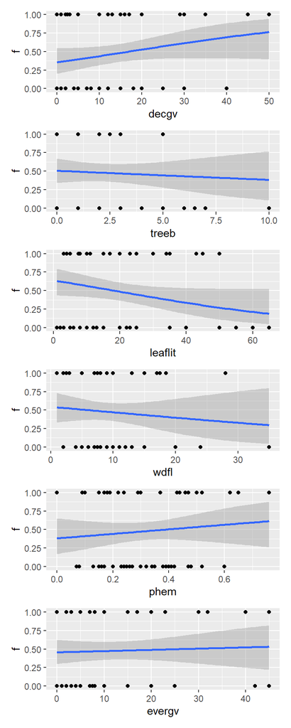

```r
l7 <- ggplot(lowa_survival, aes(decgv, f)) +
  geom_point() +
  geom_smooth(method="glm", method.args=list(family="binomial"(link="logit")))

l8 <- ggplot(lowa_survival, aes(treeb, f)) +
  geom_point() +
  geom_smooth(method="glm", method.args=list(family="binomial"(link="logit")))

l9 <- ggplot(lowa_survival, aes(leaflit, f)) +
  geom_point() +
  geom_smooth(method="glm", method.args=list(family="binomial"(link="logit")))

l10 <- ggplot(lowa_survival, aes(wdfl, f)) +
  geom_point() +
  geom_smooth(method="glm", method.args=list(family="binomial"(link="logit")))

l11 <- ggplot(lowa_survival, aes(phem, f)) +
  geom_point() +
  geom_smooth(method="glm", method.args=list(family="binomial"(link="logit")))

l12 <- ggplot(lowa_survival, aes(evergv, f)) +
  geom_point() +
  geom_smooth(method="glm", method.args=list(family="binomial"(link="logit")))

l7 / l8 / l9 / l10 / l11 / l12
```